# 🛰️ EuroSAT — Satellite Land-Use Classification System

**Dataset:** EuroSAT RGB (Sentinel-2 Satellite Images)  
**Task:** Predict whether an image shows Sea, Forest, Highway, Residential, etc.  
**Fixed Epochs:** 15 | **Platform:** CPU-safe (Windows compatible)

## 📋 Table of Contents

1. Problem Understanding
2. Exploratory Data Analysis
3. Data Pre-processing
4. Model Development
5. Training (15 Epochs)
6. Evaluation & Metrics
7. 🔍 Predict Any Image ← **The real goal**
8. Lab Report

## 1. Problem Understanding

### What does this system do?

Given any satellite image patch (64×64 pixels), this system automatically identifies the **land-use type**:

| Class | What it looks like |
| --- | --- |
| 🌾 AnnualCrop | Farmland with seasonal crops |
| 🌲 Forest | Dense tree coverage |
| 🌿 HerbaceousVegetation | Grasslands, shrubs |
| 🛣️ Highway | Roads and motorways |
| 🏭 Industrial | Factories, warehouses |
| 🐄 Pasture | Open grazing land |
| 🍇 PermanentCrop | Vineyards, orchards |
| 🏘️ Residential | Housing, suburbs |
| 🌊 River | Rivers, streams |
| 🌊 SeaLake | Sea, lakes, open water |

### Why CNN / Deep Learning?

- Raw satellite pixels have **no tabular structure** — traditional ML (SVM, RF) needs hand-crafted features
- CNNs **automatically learn** edges → textures → shapes → land-use patterns
- 27,000 images with 10 classes is large enough to train from scratch

## 2. Exploratory Data Analysis

### 2.1 Imports

```python
import os, random, warnings, zipfile, urllib.request, ssl
import numpy as np
import pandas as pd
import matplotlib.pyplot as plt
import matplotlib.patches as mpatches
import seaborn as sns
from pathlib import Path
from PIL import Image

import torch
import torch.nn as nn
import torch.optim as optim
from torch.utils.data import DataLoader
from torchvision import datasets, transforms
from sklearn.model_selection import train_test_split
from sklearn.metrics import (classification_report, confusion_matrix,
                             accuracy_score, precision_score, recall_score, f1_score)

warnings.filterwarnings('ignore')
SEED = 42
random.seed(SEED); np.random.seed(SEED); torch.manual_seed(SEED)
DEVICE = torch.device('cuda' if torch.cuda.is_available() else 'cpu')

print(f"✅ PyTorch  : {torch.__version__}")
print(f"✅ Device   : {DEVICE}")
print(f"✅ CUDA     : {torch.cuda.is_available()}")
```

```
✅ PyTorch  : 2.11.0+cpu
✅ Device   : cpu
✅ CUDA     : False
```

### 2.2 Dataset Download & Structure

```python
DATA_ROOT = Path("eurosat_data")
DATA_ROOT.mkdir(exist_ok=True)

def find_eurosat_dir(root: Path):
    """Find whichever folder contains 5+ class sub-folders."""
    for candidate in sorted(root.rglob("*")):
        if candidate.is_dir():
            subdirs = [d for d in candidate.iterdir() if d.is_dir()]
            if len(subdirs) >= 5:
                return candidate
    return None

EUROSAT_DIR = find_eurosat_dir(DATA_ROOT)

if EUROSAT_DIR is None:
    print("📥 Downloading EuroSAT …")
    zip_path = DATA_ROOT / "EuroSAT.zip"
    ctx = ssl.create_default_context()
    ctx.check_hostname = False
    ctx.verify_mode = ssl.CERT_NONE
    downloaded = False
    for url in [
        "https://madm.dfki.de/files/sentinel/EuroSAT.zip",
        "https://huggingface.co/datasets/torchgeo/eurosat/resolve/main/EuroSAT.zip",
    ]:
        try:
            opener = urllib.request.build_opener(urllib.request.HTTPSHandler(context=ctx))
            urllib.request.install_opener(opener)
            urllib.request.urlretrieve(url, zip_path)
            downloaded = True
            print(f"✅ Downloaded from {url}")
            break
        except Exception as e:
            print(f"⚠️  {e}")
    if downloaded:
        with zipfile.ZipFile(zip_path, 'r') as z:
            z.extractall(DATA_ROOT)
        zip_path.unlink()
        EUROSAT_DIR = find_eurosat_dir(DATA_ROOT)
        print(f"✅ Extracted → {EUROSAT_DIR}")
    else:
        raise RuntimeError("Download failed. Place EuroSAT folder manually in eurosat_data/")
else:
    print(f"✅ Dataset found: {EUROSAT_DIR}")

CLASS_NAMES = sorted([d.name for d in EUROSAT_DIR.iterdir() if d.is_dir()])
print(f"\n📁 {len(CLASS_NAMES)} classes:")
for cls in CLASS_NAMES:
    n = len(list((EUROSAT_DIR / cls).glob("*")))
    print(f"   {cls:<25} → {n:,} images")
```

```
✅ Dataset found: eurosat_data\2750

📁 10 classes:
   AnnualCrop                → 3,000 images
   Forest                    → 3,000 images
   HerbaceousVegetation      → 3,000 images
   Highway                   → 2,500 images
   Industrial                → 2,500 images
   Pasture                   → 2,000 images
   PermanentCrop             → 2,500 images
   Residential               → 3,000 images
   River                     → 2,500 images
   SeaLake                   → 3,000 images
```

### 2.3 Class Distribution

```
               Class  Count  Percent
          AnnualCrop   3000    11.11
              Forest   3000    11.11
HerbaceousVegetation   3000    11.11
         Residential   3000    11.11
             SeaLake   3000    11.11
             Highway   2500     9.26
       PermanentCrop   2500     9.26
          Industrial   2500     9.26
               River   2500     9.26
             Pasture   2000     7.41

Imbalance ratio: 1.50x  (near-balanced ✅)
```

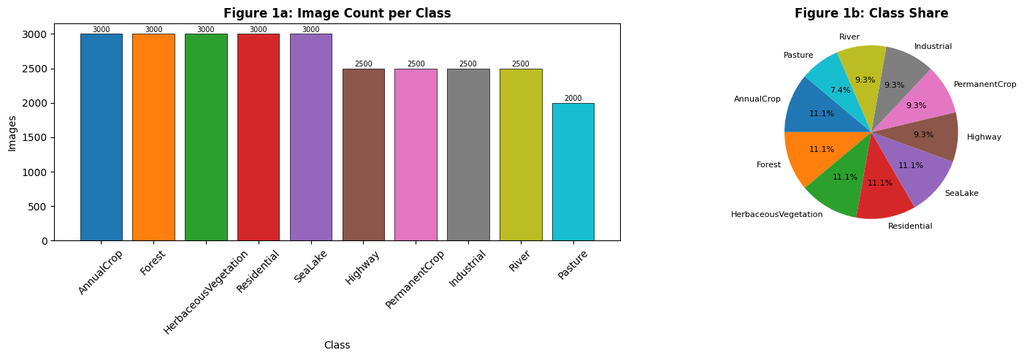

```python
class_counts = {c: len(list((EUROSAT_DIR/c).glob("*"))) for c in CLASS_NAMES}
total = sum(class_counts.values())
count_df = pd.DataFrame({"Class": list(class_counts.keys()),
                          "Count": list(class_counts.values())})
count_df["Percent"] = (count_df["Count"] / total * 100).round(2)
count_df = count_df.sort_values("Count", ascending=False)
print(count_df.to_string(index=False))
print(f"\nImbalance ratio: {count_df['Count'].max()/count_df['Count'].min():.2f}x  (near-balanced ✅)")

colors = plt.cm.tab10(np.linspace(0, 1, len(CLASS_NAMES)))
fig, axes = plt.subplots(1, 2, figsize=(16, 5))
axes[0].bar(count_df["Class"], count_df["Count"], color=colors, edgecolor="black", lw=0.5)
axes[0].set_title("Figure 1a: Image Count per Class", fontsize=12, fontweight="bold")
axes[0].set_xlabel("Class"); axes[0].set_ylabel("Images")
axes[0].tick_params(axis="x", rotation=45)
for bar, v in zip(axes[0].patches, count_df["Count"]):
    axes[0].text(bar.get_x()+bar.get_width()/2, bar.get_height()+30, str(v), ha="center", fontsize=7)
axes[1].pie(count_df["Count"], labels=count_df["Class"], autopct="%1.1f%%",
            colors=colors, startangle=140, textprops={"fontsize": 8})
axes[1].set_title("Figure 1b: Class Share", fontsize=12, fontweight="bold")
plt.tight_layout(); plt.savefig("fig1_class_dist.png", dpi=150, bbox_inches="tight"); plt.show()
```

### 2.4 Sample Images per Class

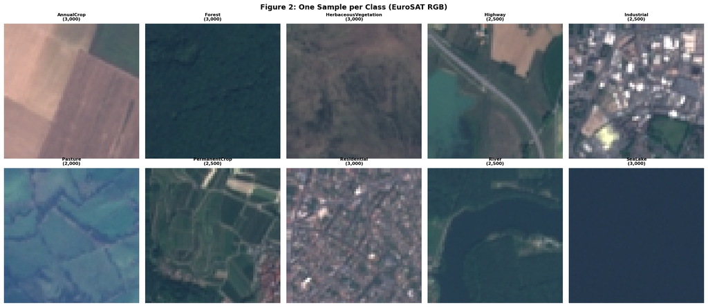

```python
fig, axes = plt.subplots(2, 5, figsize=(18, 8))
axes = axes.flatten()
for i, cls in enumerate(CLASS_NAMES):
    files = list((EUROSAT_DIR/cls).glob("*.jpg")) +             list((EUROSAT_DIR/cls).glob("*.png")) +             list((EUROSAT_DIR/cls).glob("*.tif"))
    img = Image.open(random.choice(files)).convert("RGB")
    axes[i].imshow(img)
    axes[i].set_title(f"{cls}\n({class_counts[cls]:,})", fontsize=8, fontweight="bold")
    axes[i].axis("off")
fig.suptitle("Figure 2: One Sample per Class (EuroSAT RGB)", fontsize=13, fontweight="bold")
plt.tight_layout(); plt.savefig("fig2_samples.png", dpi=150, bbox_inches="tight"); plt.show()
```

### 2.5 Pixel Intensity Distribution & Data Quality

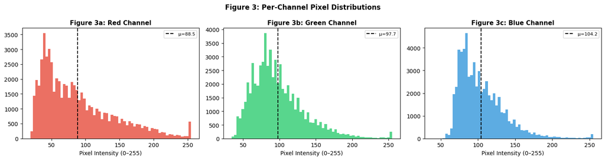

```
✅ Opened OK  : 100  |  ❌ Corrupt: 0
📐 Image sizes: {(64, 64)}
Missing values: 0 (image dataset — pixels are always present)
Outlier fix   : Normalisation to [−2, +2] via ImageNet μ/σ handles intensity outliers
```

```python
# ── Pixel distribution ───────────────────────────────────────────────────
all_files = []
for cls in CLASS_NAMES:
    flist = (list((EUROSAT_DIR/cls).glob("*.jpg")) +
             list((EUROSAT_DIR/cls).glob("*.png")) +
             list((EUROSAT_DIR/cls).glob("*.tif")))
    all_files += random.sample(flist, min(30, len(flist)))

pixels = {0: [], 1: [], 2: []}
for f in all_files:
    arr = np.array(Image.open(f).convert("RGB"))
    for c in range(3):
        pixels[c].extend(arr[:,:,c].flatten()[::20].tolist())

fig, axes = plt.subplots(1, 3, figsize=(15, 4))
for c, (name, color) in enumerate(zip(["Red","Green","Blue"],
                                       ["#e74c3c","#2ecc71","#3498db"])):
    axes[c].hist(pixels[c], bins=64, color=color, alpha=0.8, edgecolor="none")
    axes[c].axvline(np.mean(pixels[c]), color="black", linestyle="--",
                    label=f"μ={np.mean(pixels[c]):.1f}")
    axes[c].set_title(f"Figure 3{chr(97+c)}: {name} Channel", fontsize=11, fontweight="bold")
    axes[c].set_xlabel("Pixel Intensity (0–255)"); axes[c].legend(fontsize=8)
plt.suptitle("Figure 3: Per-Channel Pixel Distributions", fontsize=12, fontweight="bold")
plt.tight_layout(); plt.savefig("fig3_pixels.png", dpi=150, bbox_inches="tight"); plt.show()

# ── Data quality ──────────────────────────────────────────────────────────
ok, corrupt, sizes = 0, 0, set()
for cls in CLASS_NAMES:
    flist = (list((EUROSAT_DIR/cls).glob("*.jpg")) +
             list((EUROSAT_DIR/cls).glob("*.png")) +
             list((EUROSAT_DIR/cls).glob("*.tif")))
    for f in flist[:10]:
        try:
            img = Image.open(f).convert("RGB"); sizes.add(img.size); ok += 1
        except: corrupt += 1
print(f"\n✅ Opened OK  : {ok}  |  ❌ Corrupt: {corrupt}")
print(f"📐 Image sizes: {sizes}")
print("Missing values: 0 (image dataset — pixels are always present)")
print("Outlier fix   : Normalisation to [−2, +2] via ImageNet μ/σ handles intensity outliers")
```

## 3. Data Pre-processing

```python
IMG_SIZE   = 64
BATCH_SIZE = 64
MEAN = [0.485, 0.456, 0.406]   # ImageNet stats — standard for RGB satellite imagery
STD  = [0.229, 0.224, 0.225]

# Train: augmentation to improve generalisation (applied ONLY to train set)
train_transforms = transforms.Compose([
    transforms.Resize((IMG_SIZE, IMG_SIZE)),
    transforms.RandomHorizontalFlip(p=0.5),
    transforms.RandomVerticalFlip(p=0.5),
    transforms.RandomRotation(degrees=15),
    transforms.ColorJitter(brightness=0.2, contrast=0.2, saturation=0.1),
    transforms.ToTensor(),
    transforms.Normalize(mean=MEAN, std=STD)
])

# Val / Test / Inference: NO augmentation — deterministic
val_test_transforms = transforms.Compose([
    transforms.Resize((IMG_SIZE, IMG_SIZE)),
    transforms.ToTensor(),
    transforms.Normalize(mean=MEAN, std=STD)
])

# ── Load & stratified split 70 / 15 / 15 ─────────────────────────────────
full_dataset = datasets.ImageFolder(root=str(EUROSAT_DIR))
CLASS_NAMES  = full_dataset.classes
N            = len(full_dataset)
labels       = full_dataset.targets
indices      = list(range(N))

train_idx, temp_idx, _, temp_labels = train_test_split(
    indices, labels, test_size=0.30, stratify=labels, random_state=SEED)
val_idx, test_idx = train_test_split(
    temp_idx, test_size=0.50, stratify=temp_labels, random_state=SEED)

print(f"Total : {N:,}  |  Train: {len(train_idx):,}  |  Val: {len(val_idx):,}  |  Test: {len(test_idx):,}")

# ── Dataset wrapper ────────────────────────────────────────────────────────
class TransformSubset(torch.utils.data.Dataset):
    def __init__(self, idx, dataset, transform):
        self.idx = idx; self.dataset = dataset; self.transform = transform
    def __len__(self): return len(self.idx)
    def __getitem__(self, i):
        path, label = self.dataset.samples[self.idx[i]]
        img = Image.open(path).convert("RGB")
        return self.transform(img), label

train_ds = TransformSubset(train_idx, full_dataset, train_transforms)
val_ds   = TransformSubset(val_idx,   full_dataset, val_test_transforms)
test_ds  = TransformSubset(test_idx,  full_dataset, val_test_transforms)

# num_workers=0 → Windows safe (no multiprocessing hang)
train_loader = DataLoader(train_ds, batch_size=BATCH_SIZE, shuffle=True,  num_workers=0, pin_memory=False)
val_loader   = DataLoader(val_ds,   batch_size=BATCH_SIZE, shuffle=False, num_workers=0, pin_memory=False)
test_loader  = DataLoader(test_ds,  batch_size=BATCH_SIZE, shuffle=False, num_workers=0, pin_memory=False)

print("\n✅ DataLoaders ready — verifying one batch …")
imgs, lbs = next(iter(train_loader))
print(f"   Batch shape : {imgs.shape}   Labels: {lbs.shape}")
print(f"   Pixel range : [{imgs.min():.3f}, {imgs.max():.3f}]  (normalised ✅)")
print("\n✅ No data leakage — augmentation applied to TRAIN only.")
```

```
Total : 27,000  |  Train: 18,900  |  Val: 4,050  |  Test: 4,050

✅ DataLoaders ready — verifying one batch …
   Batch shape : torch.Size([64, 3, 64, 64])   Labels: torch.Size([64])
   Pixel range : [-2.118, 2.640]  (normalised ✅)

✅ No data leakage — augmentation applied to TRAIN only.
```

## 4. Model Development

```python
class EuroSATCNN(nn.Module):
    """
    Custom CNN — 4 double-conv blocks → Global Average Pool → FC head.

    Block depth : 3 → 32 → 64 → 128 → 256
    Spatial size: 64 → 32 → 16 → 8  → 4  → GAP → 1x1

    Regularisation:
      • BatchNorm   in every conv block   (training stability)
      • Dropout(0.4) in classifier head   (overfitting)
      • Data augmentation                 (overfitting)
      • AdamW weight decay 1e-4           (L2 regularisation)
    """
    def __init__(self, num_classes=10):
        super().__init__()

        def block(in_ch, out_ch):
            return nn.Sequential(
                nn.Conv2d(in_ch, out_ch, 3, padding=1, bias=False),
                nn.BatchNorm2d(out_ch), nn.ReLU(inplace=True),
                nn.Conv2d(out_ch, out_ch, 3, padding=1, bias=False),
                nn.BatchNorm2d(out_ch), nn.ReLU(inplace=True),
                nn.MaxPool2d(2, 2)
            )

        self.features = nn.Sequential(
            block(3,   32),
            block(32,  64),
            block(64,  128),
            block(128, 256),
        )
        self.gap = nn.AdaptiveAvgPool2d(1)
        self.classifier = nn.Sequential(
            nn.Flatten(),
            nn.Linear(256, 128), nn.ReLU(inplace=True),
            nn.Dropout(0.4),
            nn.Linear(128, num_classes)
        )

    def forward(self, x):
        return self.classifier(self.gap(self.features(x)))


model     = EuroSATCNN(num_classes=10).to(DEVICE)
criterion = nn.CrossEntropyLoss()
optimizer = optim.AdamW(model.parameters(), lr=1e-3, weight_decay=1e-4)
scheduler = optim.lr_scheduler.ReduceLROnPlateau(
                optimizer, mode='min', factor=0.5, patience=3, min_lr=1e-6)

total_p = sum(p.numel() for p in model.parameters())
print("=" * 60)
print("           EuroSATCNN  —  Model Summary")
print("=" * 60)
print(model)
print("=" * 60)
print(f"Total parameters     : {total_p:,}")
print(f"Device               : {DEVICE}")
print("\nLoss      : CrossEntropyLoss  (Softmax + NLLLoss)")
print("Optimizer : AdamW  lr=1e-3, wd=1e-4")
print("Scheduler : ReduceLROnPlateau  factor=0.5, patience=3")
```

```
============================================================
           EuroSATCNN  —  Model Summary
============================================================
EuroSATCNN(
  (features): Sequential(
    (0): Sequential(
      (0): Conv2d(3, 32, kernel_size=(3, 3), stride=(1, 1), padding=(1, 1), bias=False)
      (1): BatchNorm2d(32, eps=1e-05, momentum=0.1, affine=True, track_running_stats=True)
      (2): ReLU(inplace=True)
      (3): Conv2d(32, 32, kernel_size=(3, 3), stride=(1, 1), padding=(1, 1), bias=False)
      (4): BatchNorm2d(32, eps=1e-05, momentum=0.1, affine=True, track_running_stats=True)
      (5): ReLU(inplace=True)
      (6): MaxPool2d(kernel_size=2, stride=2, padding=0, dilation=1, ceil_mode=False)
    )
    (1): Sequential(
      (0): Conv2d(32, 64, kernel_size=(3, 3), stride=(1, 1), padding=(1, 1), bias=False)
      (1): BatchNorm2d(64, eps=1e-05, momentum=0.1, affine=True, track_running_stats=True)
      (2): ReLU(inplace=True)
      (3): Conv2d(64, 64, kernel_size=(3, 3), stride=(1, 1), padding=(1, 1), bias=False)
      (4): BatchNorm2d(64, eps=1e-05, momentum=0.1, affine=True, track_running_stats=True)
      (5): ReLU(inplace=True)
      (6): MaxPool2d(kernel_size=2, stride=2, padding=0, dilation=1, ceil_mode=False)
    )
    (2): Sequential(
      (0): Conv2d(64, 128, kernel_size=(3, 3), stride=(1, 1), padding=(1, 1), bias=False)
      (1): BatchNorm2d(128, eps=1e-05, momentum=0.1, affine=True, track_running_stats=True)
      (2): ReLU(inplace=True)
      (3): Conv2d(128, 128, kernel_size=(3, 3), stride=(1, 1), padding=(1, 1), bias=False)
      (4): BatchNorm2d(128, eps=1e-05, momentum=0.1, affine=True, track_running_stats=True)
      (5): ReLU(inplace=True)
      (6): MaxPool2d(kernel_size=2, stride=2, padding=0, dilation=1, ceil_mode=False)
    )
    (3): Sequential(
      (0): Conv2d(128, 256, kernel_size=(3, 3), stride=(1, 1), padding=(1, 1), bias=False)
      (1): BatchNorm2d(256, eps=1e-05, momentum=0.1, affine=True, track_running_stats=True)
      (2): ReLU(inplace=True)
      (3): Conv2d(256, 256, kernel_size=(3, 3), stride=(1, 1), padding=(1, 1), bias=False)
      (4): BatchNorm2d(256, eps=1e-05, momentum=0.1, affine=True, track_running_stats=True)
      (5): ReLU(inplace=True)
      (6): MaxPool2d(kernel_size=2, stride=2, padding=0, dilation=1, ceil_mode=False)
    )
  )
  (gap): AdaptiveAvgPool2d(output_size=1)
  (classifier): Sequential(
    (0): Flatten(start_dim=1, end_dim=-1)
    (1): Linear(in_features=256, out_features=128, bias=True)
    (2): ReLU(inplace=True)
    (3): Dropout(p=0.4, inplace=False)
    (4): Linear(in_features=128, out_features=10, bias=True)
  )
)
============================================================
Total parameters     : 1,207,402
Device               : cpu

Loss      : CrossEntropyLoss  (Softmax + NLLLoss)
Optimizer : AdamW  lr=1e-3, wd=1e-4
Scheduler : ReduceLROnPlateau  factor=0.5, patience=3
```

## 5. Training — Fixed 15 Epochs

```python
from tqdm import tqdm

def train_epoch(model, loader, criterion, optimizer, device):
    model.train()
    loss_sum, correct, total = 0.0, 0, 0

    pbar = tqdm(loader, desc="  Train", leave=False, unit="batch",
                bar_format="{l_bar}{bar:25}{r_bar}")

    for imgs, lbls in pbar:
        imgs, lbls = imgs.to(device), lbls.to(device)
        optimizer.zero_grad()
        out  = model(imgs)
        loss = criterion(out, lbls)
        loss.backward(); optimizer.step()

        loss_sum += loss.item() * imgs.size(0)
        correct  += (out.argmax(1) == lbls).sum().item()
        total    += imgs.size(0)

        pbar.set_postfix(loss=f"{loss_sum/total:.4f}",
                         acc=f"{correct/total*100:.2f}%")

    return loss_sum / total, correct / total


def eval_epoch(model, loader, criterion, device):
    model.eval()
    loss_sum, correct, total = 0.0, 0, 0
    preds_all, labels_all = [], []

    pbar = tqdm(loader, desc="    Val", leave=False, unit="batch",
                bar_format="{l_bar}{bar:25}{r_bar}")

    with torch.no_grad():
        for imgs, lbls in pbar:
            imgs, lbls = imgs.to(device), lbls.to(device)
            out  = model(imgs)
            loss = criterion(out, lbls)
            loss_sum += loss.item() * imgs.size(0)
            p = out.argmax(1)
            correct  += (p == lbls).sum().item()
            total    += imgs.size(0)
            preds_all.extend(p.cpu().numpy())
            labels_all.extend(lbls.cpu().numpy())

            pbar.set_postfix(loss=f"{loss_sum/total:.4f}",
                             acc=f"{correct/total*100:.2f}%")

    return loss_sum / total, correct / total, preds_all, labels_all


# ── Training loop ─────────────────────────────────────────────────────────
NUM_EPOCHS = 15
history    = {k: [] for k in ['train_loss', 'val_loss', 'train_acc', 'val_acc']}
best_val_loss = float('inf')
best_wts      = None

print(f"🚀 Training EuroSATCNN for {NUM_EPOCHS} fixed epochs on {DEVICE}")
print("=" * 72)
print(f"{'Ep':>3} | {'Train Loss':>10} | {'Val Loss':>9} | {'Train Acc':>9} | {'Val Acc':>8} | {'LR':>8}")
print("-" * 72)

epoch_bar = tqdm(range(1, NUM_EPOCHS + 1), desc="Epochs", unit="ep",
                 bar_format="{l_bar}{bar:30}{r_bar}")

for ep in epoch_bar:
    tr_l, tr_a          = train_epoch(model, train_loader, criterion, optimizer, DEVICE)
    va_l, va_a, _, _    = eval_epoch(model, val_loader, criterion, DEVICE)
    scheduler.step(va_l)
    lr = optimizer.param_groups[0]['lr']

    history['train_loss'].append(tr_l)
    history['val_loss'].append(va_l)
    history['train_acc'].append(tr_a)
    history['val_acc'].append(va_a)

    if va_l < best_val_loss:
        best_val_loss = va_l
        best_wts = {k: v.clone() for k, v in model.state_dict().items()}
        flag = " ✅ best"
    else:
        flag = ""

    # Update outer bar with live metrics
    epoch_bar.set_postfix(val_loss=f"{va_l:.4f}", val_acc=f"{va_a*100:.2f}%", lr=f"{lr:.6f}")

    print(f"{ep:>3} | {tr_l:>10.4f} | {va_l:>9.4f} | "
          f"{tr_a*100:>8.2f}% | {va_a*100:>7.2f}% | {lr:>8.6f}{flag}")

print("=" * 72)
model.load_state_dict(best_wts)
print(f"\n✅ Best weights restored  (val_loss = {best_val_loss:.4f})")
print(f"✅ Best Val Accuracy      : {max(history['val_acc'])*100:.2f}%")

torch.save(model.state_dict(), "eurosat_cnn.pth")
print("💾 Model saved → eurosat_cnn.pth")
```

```
🚀 Training EuroSATCNN for 15 fixed epochs on cpu
========================================================================
 Ep | Train Loss |  Val Loss | Train Acc |  Val Acc |       LR
------------------------------------------------------------------------
```

```
  1 |     0.6173 |    1.0064 |    79.33% |   71.85% | 0.001000 ✅ best
```

```
  2 |     0.5148 |    0.5357 |    83.14% |   82.15% | 0.001000 ✅ best
```

```
  3 |     0.4464 |    0.3497 |    85.66% |   88.35% | 0.001000 ✅ best
```

```
  4 |     0.4162 |    0.3091 |    86.70% |   89.33% | 0.001000 ✅ best
```

```
  5 |     0.3584 |    0.4150 |    88.31% |   86.72% | 0.001000
```

```
  6 |     0.3243 |    0.3904 |    89.41% |   85.88% | 0.001000
```

```
  7 |     0.2972 |    0.4248 |    90.38% |   86.47% | 0.001000
```

```
  8 |     0.2852 |    0.2164 |    90.80% |   92.17% | 0.001000 ✅ best
```

```
  9 |     0.2547 |    0.2620 |    91.65% |   91.14% | 0.001000
```

```
 10 |     0.2452 |    0.2949 |    92.08% |   91.33% | 0.001000
```

```
 11 |     0.2313 |    0.1964 |    92.28% |   93.41% | 0.001000 ✅ best
```

```
 12 |     0.2259 |    0.1759 |    92.70% |   93.78% | 0.001000 ✅ best
```

```
 13 |     0.2135 |    0.1871 |    93.00% |   93.46% | 0.001000
```

```
 14 |     0.2095 |    0.3000 |    93.04% |   90.20% | 0.001000
```

```
 15 |     0.1938 |    0.3356 |    93.59% |   89.28% | 0.001000
========================================================================

✅ Best weights restored  (val_loss = 0.1759)
✅ Best Val Accuracy      : 93.78%
💾 Model saved → eurosat_cnn.pth
```

## 6. Evaluation & Metrics

### 6.1 Training Curves

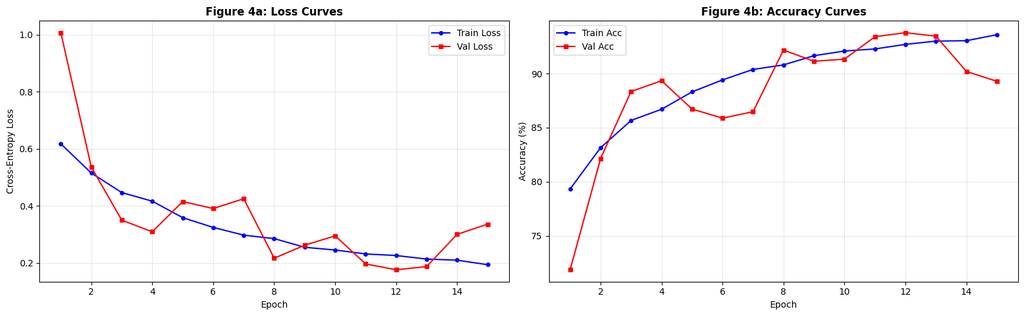

```python
ep_range = range(1, NUM_EPOCHS + 1)
fig, axes = plt.subplots(1, 2, figsize=(16, 5))

axes[0].plot(ep_range, history['train_loss'], 'b-o', ms=4, label='Train Loss')
axes[0].plot(ep_range, history['val_loss'],   'r-s', ms=4, label='Val Loss')
axes[0].set_title("Figure 4a: Loss Curves", fontsize=12, fontweight='bold')
axes[0].set_xlabel("Epoch"); axes[0].set_ylabel("Cross-Entropy Loss")
axes[0].legend(); axes[0].grid(alpha=0.3)

axes[1].plot(ep_range, [a*100 for a in history['train_acc']], 'b-o', ms=4, label='Train Acc')
axes[1].plot(ep_range, [a*100 for a in history['val_acc']],   'r-s', ms=4, label='Val Acc')
axes[1].set_title("Figure 4b: Accuracy Curves", fontsize=12, fontweight='bold')
axes[1].set_xlabel("Epoch"); axes[1].set_ylabel("Accuracy (%)")
axes[1].legend(); axes[1].grid(alpha=0.3)

plt.tight_layout(); plt.savefig("fig4_curves.png", dpi=150, bbox_inches='tight'); plt.show()
```

### 6.2 Test Set Performance

```python
test_loss, test_acc, y_pred, y_true = eval_epoch(model, test_loader, criterion, DEVICE)

acc  = accuracy_score(y_true, y_pred)
prec = precision_score(y_true, y_pred, average='weighted')
rec  = recall_score(y_true, y_pred, average='weighted')
f1   = f1_score(y_true, y_pred, average='weighted')

print("=" * 55)
print("        FINAL TEST SET RESULTS")
print("=" * 55)
print(f"  Accuracy          : {acc*100:.2f}%")
print(f"  Weighted Precision: {prec:.4f}")
print(f"  Weighted Recall   : {rec:.4f}")
print(f"  Weighted F1-Score : {f1:.4f}")
print(f"  Test Loss         : {test_loss:.4f}")
print("=" * 55)
print()
print(classification_report(y_true, y_pred, target_names=CLASS_NAMES, digits=4))
```

```
=======================================================
        FINAL TEST SET RESULTS
=======================================================
  Accuracy          : 94.62%
  Weighted Precision: 0.9472
  Weighted Recall   : 0.9462
  Weighted F1-Score : 0.9459
  Test Loss         : 0.1540
=======================================================

                      precision    recall  f1-score   support

          AnnualCrop     0.9216    0.9400    0.9307       450
              Forest     0.9393    0.9978    0.9677       450
HerbaceousVegetation     0.9321    0.8844    0.9076       450
             Highway     0.9703    0.9573    0.9638       375
          Industrial     1.0000    0.9067    0.9510       375
             Pasture     0.9439    0.9533    0.9486       300
       PermanentCrop     0.9452    0.8747    0.9086       375
         Residential     0.9091    1.0000    0.9524       450
               River     0.9349    0.9573    0.9460       375
             SeaLake     0.9843    0.9778    0.9810       450

            accuracy                         0.9462      4050
           macro avg     0.9481    0.9449    0.9457      4050
        weighted avg     0.9472    0.9462    0.9459      4050
```

### 6.3 Confusion Matrix

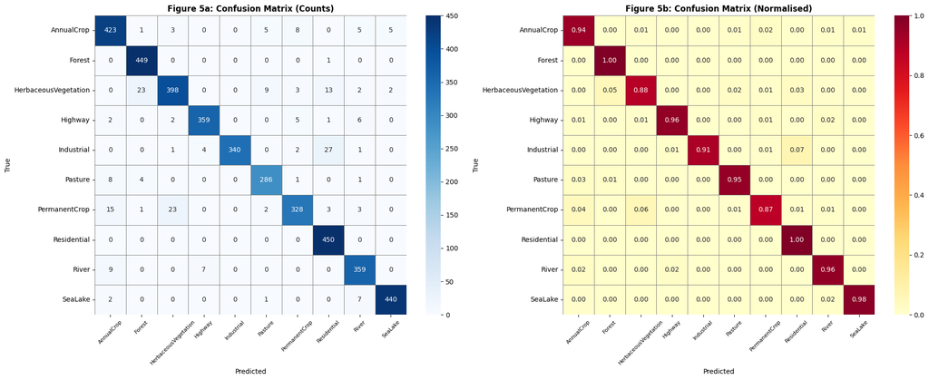

```python
cm      = confusion_matrix(y_true, y_pred)
cm_norm = cm.astype(float) / cm.sum(axis=1, keepdims=True)

fig, axes = plt.subplots(1, 2, figsize=(20, 8))
sns.heatmap(cm, annot=True, fmt='d', cmap='Blues', ax=axes[0],
            xticklabels=CLASS_NAMES, yticklabels=CLASS_NAMES,
            linewidths=0.4, linecolor='gray')
axes[0].set_title("Figure 5a: Confusion Matrix (Counts)", fontsize=12, fontweight='bold')
axes[0].set_xlabel("Predicted"); axes[0].set_ylabel("True")
axes[0].tick_params(axis='x', rotation=45, labelsize=8)

sns.heatmap(cm_norm, annot=True, fmt='.2f', cmap='YlOrRd', ax=axes[1],
            xticklabels=CLASS_NAMES, yticklabels=CLASS_NAMES,
            linewidths=0.4, linecolor='gray', vmin=0, vmax=1)
axes[1].set_title("Figure 5b: Confusion Matrix (Normalised)", fontsize=12, fontweight='bold')
axes[1].set_xlabel("Predicted"); axes[1].set_ylabel("True")
axes[1].tick_params(axis='x', rotation=45, labelsize=8)

plt.tight_layout(); plt.savefig("fig5_cm.png", dpi=150, bbox_inches='tight'); plt.show()
```

### 6.4 Per-Class F1-Score & Results Summary

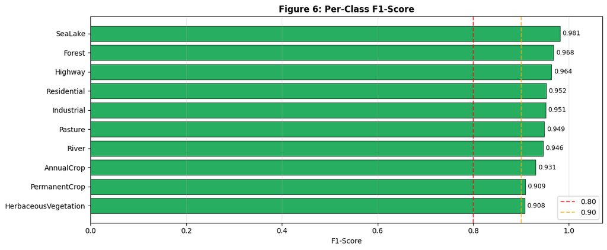

```
=== RESULTS SUMMARY ===
            Metric  Value
          Accuracy 94.62%
Weighted Precision 0.9472
   Weighted Recall 0.9462
       Weighted F1 0.9459
         Test Loss 0.1540

Train–Val gap : -0.19%  →  ✅ Well-generalised
```

```python
pc_f1  = f1_score(y_true, y_pred, average=None)
pc_pr  = precision_score(y_true, y_pred, average=None)
pc_rec = recall_score(y_true, y_pred, average=None)

res_df = pd.DataFrame({
    'Class': CLASS_NAMES, 'Precision': pc_pr,
    'Recall': pc_rec,     'F1-Score': pc_f1
}).sort_values('F1-Score', ascending=True)

fig, ax = plt.subplots(figsize=(12, 5))
cols = ['#e74c3c' if v < 0.80 else '#f39c12' if v < 0.90 else '#27ae60'
        for v in res_df['F1-Score']]
bars = ax.barh(res_df['Class'], res_df['F1-Score'], color=cols, edgecolor='black', lw=0.5)
for bar, v in zip(bars, res_df['F1-Score']):
    ax.text(bar.get_width()+0.005, bar.get_y()+bar.get_height()/2,
            f'{v:.3f}', va='center', fontsize=9)
ax.axvline(0.80, color='red',    linestyle='--', alpha=0.7, label='0.80')
ax.axvline(0.90, color='orange', linestyle='--', alpha=0.7, label='0.90')
ax.set_xlim(0, 1.07); ax.set_xlabel("F1-Score")
ax.set_title("Figure 6: Per-Class F1-Score", fontsize=12, fontweight='bold')
ax.legend(); ax.grid(axis='x', alpha=0.3)
plt.tight_layout(); plt.savefig("fig6_f1.png", dpi=150, bbox_inches='tight'); plt.show()

# Summary table
print("\n=== RESULTS SUMMARY ===")
summary = pd.DataFrame({
    'Metric': ['Accuracy','Weighted Precision','Weighted Recall','Weighted F1','Test Loss'],
    'Value' : [f'{acc*100:.2f}%', f'{prec:.4f}', f'{rec:.4f}', f'{f1:.4f}', f'{test_loss:.4f}']
})
print(summary.to_string(index=False))

gap = max(history['train_acc']) - max(history['val_acc'])
print(f"\nTrain–Val gap : {gap*100:.2f}%  →  ", end="")
if gap < 0.05: print("✅ Well-generalised")
elif gap < 0.10: print("⚠️  Mild overfitting")
else: print("❌ Overfitting — increase regularisation")
```

## 7. 🔍 Predict Any Image — The Real Goal

This is the core purpose of the system.  
**How to use:**

- Drop any satellite image file into the same folder as this notebook
- Change `IMAGE_PATH` below to your file name
- Run the cell — the model will tell you what land type it sees

> You can also point it at any image from the test set to verify predictions.

```
ℹ️  No IMAGE_PATH set — running demo on a random TEST SET image.
   Set IMAGE_PATH = 'your_file.jpg' to classify your own image.

   Demo image : River_647.jpg
   True class : 🌊 River
```

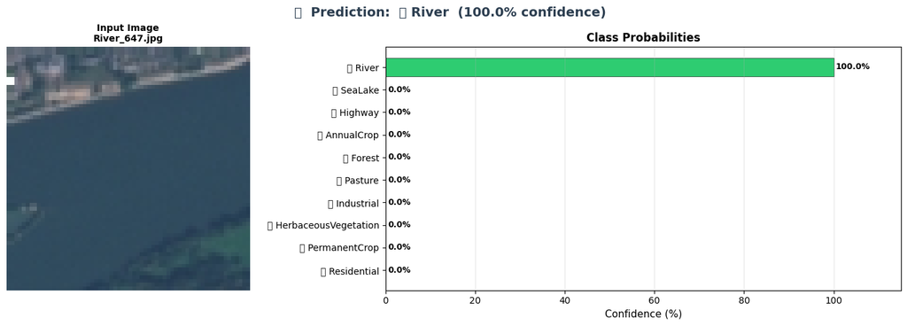

```
=======================================================
  🏆 PREDICTION  : 🌊  River
  📊 CONFIDENCE  : 99.98%
=======================================================

Full ranking:
   1. 🌊 River                     100.0%  █████████████████████████████
   2. 🌊 SeaLake                     0.0%
   3. 🛣️ Highway                     0.0%
   4. 🌾 AnnualCrop                  0.0%
   5. 🌲 Forest                      0.0%
   6. 🐄 Pasture                     0.0%
   7. 🏭 Industrial                  0.0%
   8. 🌿 HerbaceousVegetation        0.0%
   9. 🍇 PermanentCrop               0.0%
  10. 🏘️ Residential                 0.0%

  Ground truth : River
  Result       : ✅ CORRECT
```

```python
# ════════════════════════════════════════════════════════════════
# 🔍  PREDICT A SINGLE IMAGE
# ════════════════════════════════════════════════════════════════
# ▶ Change this path to any image file you want to classify
IMAGE_PATH = None   # e.g.  "my_satellite_image.jpg"
#                           or  r"C:/Users/you/Downloads/patch.jpg"
# ════════════════════════════════════════════════════════════════

# ── Emoji map for pretty display ─────────────────────────────────────────
CLASS_EMOJI = {
    "AnnualCrop":            "🌾",
    "Forest":                "🌲",
    "HerbaceousVegetation":  "🌿",
    "Highway":               "🛣️",
    "Industrial":            "🏭",
    "Pasture":               "🐄",
    "PermanentCrop":         "🍇",
    "Residential":           "🏘️",
    "River":                 "🌊",
    "SeaLake":               "🌊",
}

def predict_image(image_path, model, class_names, transform, device):
    """Load one image, run inference, return sorted class probabilities."""
    model.eval()
    img = Image.open(image_path).convert("RGB")
    tensor = transform(img).unsqueeze(0).to(device)   # add batch dim
    with torch.no_grad():
        logits = model(tensor)
        probs  = torch.softmax(logits, dim=1).squeeze().cpu().numpy()
    ranked = sorted(zip(class_names, probs), key=lambda x: x[1], reverse=True)
    return img, ranked


def show_prediction(image_path, model, class_names, transform, device):
    """Visualise the image alongside a confidence bar chart."""
    img, ranked = predict_image(image_path, model, class_names, transform, device)
    top_class, top_prob = ranked[0]

    fig, axes = plt.subplots(1, 2, figsize=(14, 5),
                             gridspec_kw={'width_ratios': [1, 2]})

    # ── Left: the satellite image ─────────────────────────────────────────
    axes[0].imshow(img)
    axes[0].set_title(
        f"Input Image\n{Path(image_path).name}", fontsize=10, fontweight='bold')
    axes[0].axis('off')

    # ── Right: confidence bar chart ───────────────────────────────────────
    names  = [f"{CLASS_EMOJI.get(c,'🗺️')} {c}" for c, _ in ranked]
    probs  = [p for _, p in ranked]
    colors_bar = ['#2ecc71' if i == 0 else '#3498db' if probs[i] > 0.1
                  else '#bdc3c7' for i in range(len(probs))]

    bars = axes[1].barh(names[::-1], [p*100 for p in probs[::-1]],
                         color=colors_bar[::-1], edgecolor='black', lw=0.4)
    for bar, p in zip(bars, probs[::-1]):
        axes[1].text(bar.get_width() + 0.5, bar.get_y() + bar.get_height()/2,
                     f'{p*100:.1f}%', va='center', fontsize=9, fontweight='bold')
    axes[1].set_xlim(0, 115)
    axes[1].set_xlabel("Confidence (%)", fontsize=11)
    axes[1].set_title("Class Probabilities", fontsize=12, fontweight='bold')
    axes[1].grid(axis='x', alpha=0.3)

    fig.suptitle(
        f"🛰️  Prediction:  {CLASS_EMOJI.get(top_class,'🗺️')} {top_class}  "
        f"({top_prob*100:.1f}% confidence)",
        fontsize=14, fontweight='bold', color='#2c3e50')
    plt.tight_layout()
    plt.savefig("prediction_result.png", dpi=150, bbox_inches='tight')
    plt.show()

    print("\n" + "="*55)
    print(f"  🏆 PREDICTION  : {CLASS_EMOJI.get(top_class,'🗺️')}  {top_class}")
    print(f"  📊 CONFIDENCE  : {top_prob*100:.2f}%")
    print("="*55)
    print("\nFull ranking:")
    for rank, (cls, prob) in enumerate(ranked, 1):
        bar = "█" * int(prob * 30)
        print(f"  {rank:>2}. {CLASS_EMOJI.get(cls,'🗺️')} {cls:<25} {prob*100:5.1f}%  {bar}")
    return top_class, top_prob


# ── Run prediction ────────────────────────────────────────────────────────
if IMAGE_PATH is None:
    # ── Demo: pick a random image from the test set ───────────────────────
    print("ℹ️  No IMAGE_PATH set — running demo on a random TEST SET image.")
    print("   Set IMAGE_PATH = 'your_file.jpg' to classify your own image.\n")
    rand_test_idx = random.choice(test_idx)
    demo_path, true_label_idx = full_dataset.samples[rand_test_idx]
    true_label = CLASS_NAMES[true_label_idx]
    print(f"   Demo image : {Path(demo_path).name}")
    print(f"   True class : {CLASS_EMOJI.get(true_label,'🗺️')} {true_label}\n")
    pred_class, pred_conf = show_prediction(
        demo_path, model, CLASS_NAMES, val_test_transforms, DEVICE)
    match = "✅ CORRECT" if pred_class == true_label else "❌ WRONG"
    print(f"\n  Ground truth : {true_label}")
    print(f"  Result       : {match}")
else:
    # ── User-supplied image ───────────────────────────────────────────────
    if not Path(IMAGE_PATH).exists():
        print(f"❌ File not found: {IMAGE_PATH}")
        print("   Make sure the file is in the same folder as this notebook.")
    else:
        show_prediction(IMAGE_PATH, model, CLASS_NAMES, val_test_transforms, DEVICE)
```

### 7.2 Batch Predict — Multiple Images at Once

```
ℹ️  Demo: predicting 8 random test-set images

Image                               True                      Predicted                   Conf  OK?
----------------------------------------------------------------------------------------------------
PermanentCrop_2437.jpg              PermanentCrop             PermanentCrop              92.1%  ✅
Residential_2707.jpg                Residential               Residential               100.0%  ✅
Highway_2296.jpg                    Highway                   Highway                   100.0%  ✅
Highway_344.jpg                     Highway                   Highway                    94.5%  ✅
Pasture_1835.jpg                    Pasture                   Pasture                    83.5%  ✅
Pasture_1549.jpg                    Pasture                   Pasture                    95.3%  ✅
Forest_2374.jpg                     Forest                    Forest                    100.0%  ✅
Forest_2983.jpg                     Forest                    Forest                     99.9%  ✅

🎯 Demo accuracy: 8/8 = 100%
```

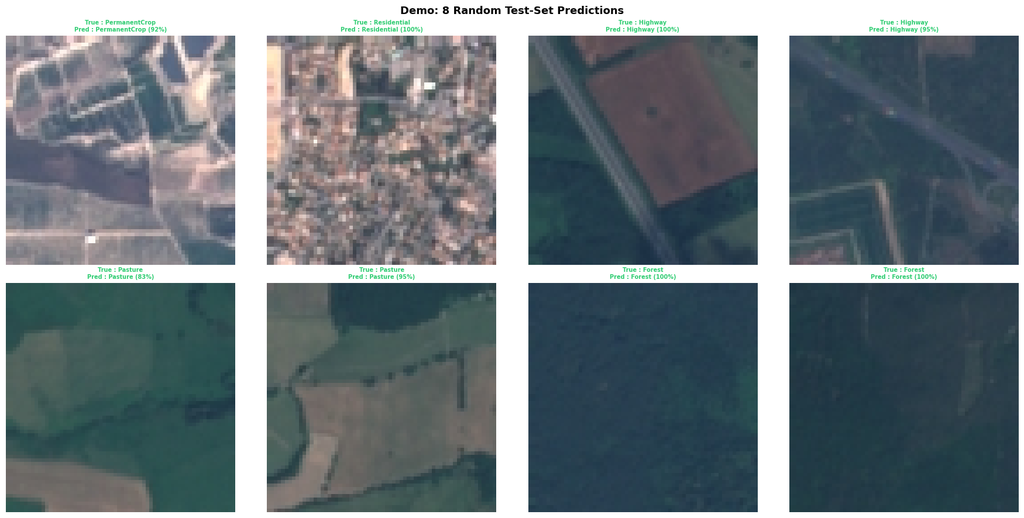

```python
# ════════════════════════════════════════════════════════════════
# 📂  BATCH PREDICT A FOLDER OF IMAGES
# ════════════════════════════════════════════════════════════════
# ▶ Set this to a folder containing satellite images, e.g.:
#       PREDICT_FOLDER = "my_images"
#       PREDICT_FOLDER = r"C:/Users/you/Downloads/patches"
PREDICT_FOLDER = None   # Set to your folder path
# ════════════════════════════════════════════════════════════════

def batch_predict(folder, model, class_names, transform, device, max_show=12):
    """Predict all images in a folder and display a grid."""
    folder = Path(folder)
    image_files = (list(folder.glob("*.jpg")) + list(folder.glob("*.png")) +
                   list(folder.glob("*.tif")) + list(folder.glob("*.jpeg")))
    if not image_files:
        print(f"❌ No images found in {folder}")
        return

    print(f"📂 Found {len(image_files)} image(s) in {folder}\n")
    results = []
    for f in image_files:
        try:
            _, ranked = predict_image(f, model, class_names, transform, device)
            results.append((f, ranked[0][0], ranked[0][1]))
        except Exception as e:
            print(f"  ⚠️  Skipped {f.name}: {e}")

    # ── Print results table ───────────────────────────────────────────────
    print(f"{'File':<35} {'Prediction':<25} {'Confidence':>10}")
    print("-" * 72)
    for f, cls, prob in results:
        emoji = CLASS_EMOJI.get(cls, '🗺️')
        print(f"{f.name:<35} {emoji} {cls:<22} {prob*100:>9.1f}%")

    # ── Image grid ────────────────────────────────────────────────────────
    show = results[:max_show]
    cols = 4; rows = (len(show) + cols - 1) // cols
    fig, axes = plt.subplots(rows, cols, figsize=(cols*4, rows*3.5))
    axes = np.array(axes).flatten()
    for i, (f, cls, prob) in enumerate(show):
        img = Image.open(f).convert("RGB")
        axes[i].imshow(img)
        axes[i].set_title(
            f"{CLASS_EMOJI.get(cls,'🗺️')} {cls}\n{prob*100:.1f}%",
            fontsize=8, fontweight='bold')
        axes[i].axis('off')
    for j in range(len(show), len(axes)):
        axes[j].axis('off')
    fig.suptitle("Batch Prediction Results", fontsize=13, fontweight='bold')
    plt.tight_layout()
    plt.savefig("batch_predictions.png", dpi=150, bbox_inches='tight')
    plt.show()
    return results


# ── Run batch prediction ──────────────────────────────────────────────────
if PREDICT_FOLDER is None:
    print("ℹ️  Demo: predicting 8 random test-set images\n")
    demo_indices = random.sample(test_idx, 8)

    fig, axes = plt.subplots(2, 4, figsize=(18, 9))
    axes = axes.flatten()
    print(f"{'Image':<35} {'True':<25} {'Predicted':<25} {'Conf':>6}  OK?")
    print("-" * 100)
    correct_count = 0
    for i, idx in enumerate(demo_indices):
        path, true_idx = full_dataset.samples[idx]
        true_cls = CLASS_NAMES[true_idx]
        img, ranked = predict_image(path, model, CLASS_NAMES, val_test_transforms, DEVICE)
        pred_cls, conf = ranked[0]
        ok = pred_cls == true_cls
        if ok: correct_count += 1
        tick = "✅" if ok else "❌"
        print(f"{Path(path).name:<35} {true_cls:<25} {pred_cls:<25} {conf*100:>5.1f}%  {tick}")
        color = '#2ecc71' if ok else '#e74c3c'
        axes[i].imshow(img)
        axes[i].set_title(
            f"True : {true_cls}\nPred : {pred_cls} ({conf*100:.0f}%)",
            fontsize=7, color=color, fontweight='bold')
        axes[i].axis('off')
    print(f"\n🎯 Demo accuracy: {correct_count}/8 = {correct_count/8*100:.0f}%")
    fig.suptitle("Demo: 8 Random Test-Set Predictions", fontsize=13, fontweight='bold')
    plt.tight_layout(); plt.savefig("demo_predictions.png", dpi=150, bbox_inches='tight')
    plt.show()
else:
    batch_predict(PREDICT_FOLDER, model, CLASS_NAMES, val_test_transforms, DEVICE)
```

### 7.3 Where Does the Model Fail? — Misclassified Samples

```
Misclassified : 218 / 4050 (5.4%)
Correct       : 3832 / 4050 (94.6%)
```

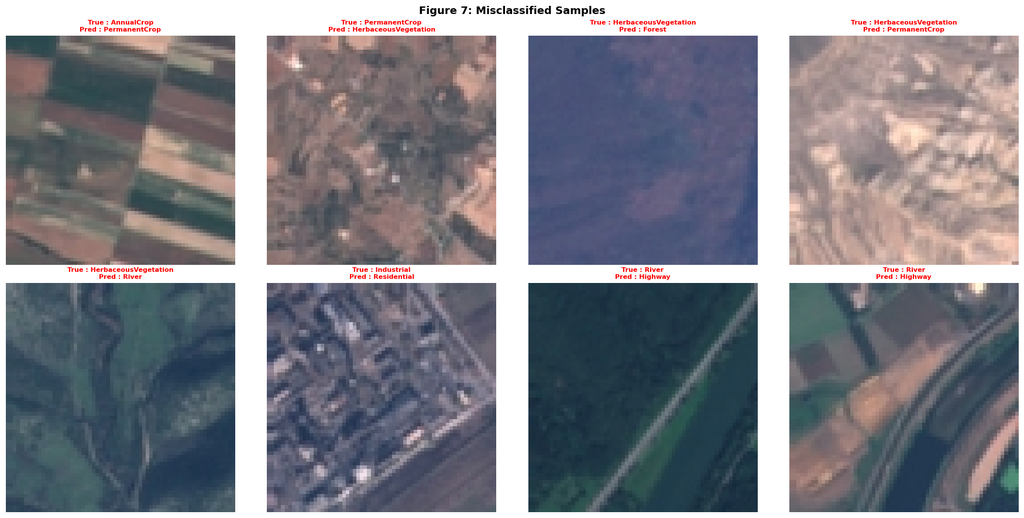

```python
wrong_idx = [i for i, (p, t) in enumerate(zip(y_pred, y_true)) if p != t]
print(f"Misclassified : {len(wrong_idx)} / {len(y_true)} ({len(wrong_idx)/len(y_true)*100:.1f}%)")
print(f"Correct       : {len(y_true)-len(wrong_idx)} / {len(y_true)} ({(1-len(wrong_idx)/len(y_true))*100:.1f}%)")

if len(wrong_idx) >= 8:
    sample_wrong = random.sample(wrong_idx, 8)
    fig, axes = plt.subplots(2, 4, figsize=(18, 9))
    axes = axes.flatten()
    for plot_i, wi in enumerate(sample_wrong):
        img_t, _ = test_ds[wi]
        img_np = img_t.numpy().transpose(1,2,0)
        img_np = np.clip(img_np * np.array(STD) + np.array(MEAN), 0, 1)
        axes[plot_i].imshow(img_np)
        axes[plot_i].set_title(
            f"True : {CLASS_NAMES[y_true[wi]]}\nPred : {CLASS_NAMES[y_pred[wi]]}",
            fontsize=8, color='red', fontweight='bold')
        axes[plot_i].axis('off')
    fig.suptitle("Figure 7: Misclassified Samples", fontsize=13, fontweight='bold')
    plt.tight_layout(); plt.savefig("fig7_misclassified.png", dpi=150, bbox_inches='tight')
    plt.show()
```